# Statistical Inference Project

Illustrate via simulation and associated explanatory text the properties of the distribution of the mean of 40 exponentials. You should 1. Show the sample mean and compare it to the theoretical mean of the distribution. 2. Show how variable the sample is (via variance) and compare it to the theoretical variance of the distribution. 3. Show that the distribution is approximately normal.

To run the simulation, we will set a seed value and then create a list of the means of each simulation result. In this example, a simulation will have 40 items and lambda = 0.2.

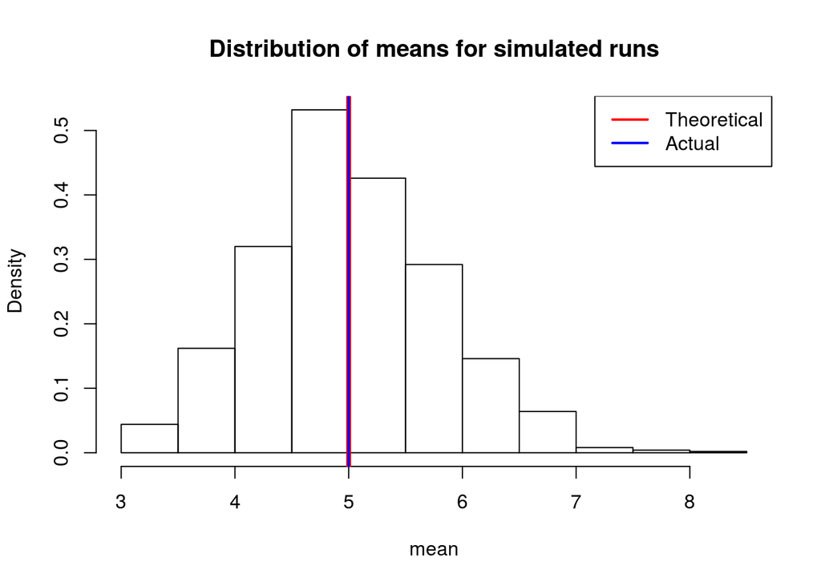

```r
set.seed(100)
mnsrexp = NULL
for (i in 1:1000) mnsrexp = c(mnsrexp,mean(rexp(40,0.2)))
hist(mnsrexp,
     main="Distribution of means for simulated runs",
     xlab="mean",
     prob=TRUE)
abline(v=5,col="red",lwd=4)
abline(v=mean(mnsrexp),col="blue",lwd=2)
legend("topright",c('Theoretical','Actual'),col=c('red','blue'),lwd=2)
```

The theoretical mean of an exponential distribution is 1/lambda, so in this case

```r
1/0.2
```

```
## [1] 5
```

The mean of the sample is:

```r
mean(mnsrexp)
```

```
## [1] 4.999702
```

This value is very close to the theoretical value of 5.0.

The theoretical variance of the exponential distribution is calculated as (1/lambda)^2/n

```r
(1/0.2)^2/40
```

```
## [1] 0.625
```

The variance of this sample is calculated:

```r
var(mnsrexp)
```

```
## [1] 0.6432442
```

This is close to the theoretical value of 0.625.

To compare this distribution to a normal distribution, we can overlay the histogram with a normal distirbution plot. It is clear that the plot closely follows the histogram.

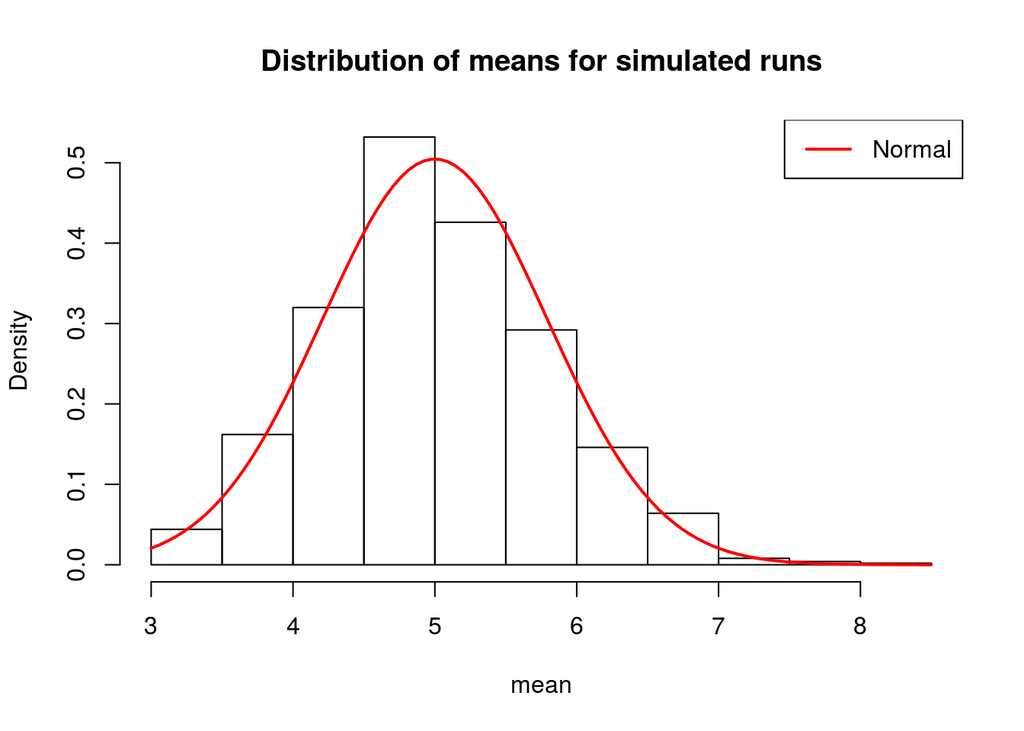